# AV新法施行後のポルノ発売状況

zombie, uncorrelated

2023/03/16

# 概況

- 総集編/ベストは除外して評価
- 2022年10月までは目立った変化は無かった。昨年比で7月が増、8月が減、9月が増、10月が微減。
- 11月は発売タイトル数では影響があるようにみえる。昨月比、昨年比で減少。AV新法の改正を訴えているポルノ女優の出演作品数は変わらず。
- 12月以降も目立った変化は無かった。昨年比で増加している。

# DVD/Blu-ray発売タイトル数の状況

## DVD/Blu-ray発売タイトル数の推移

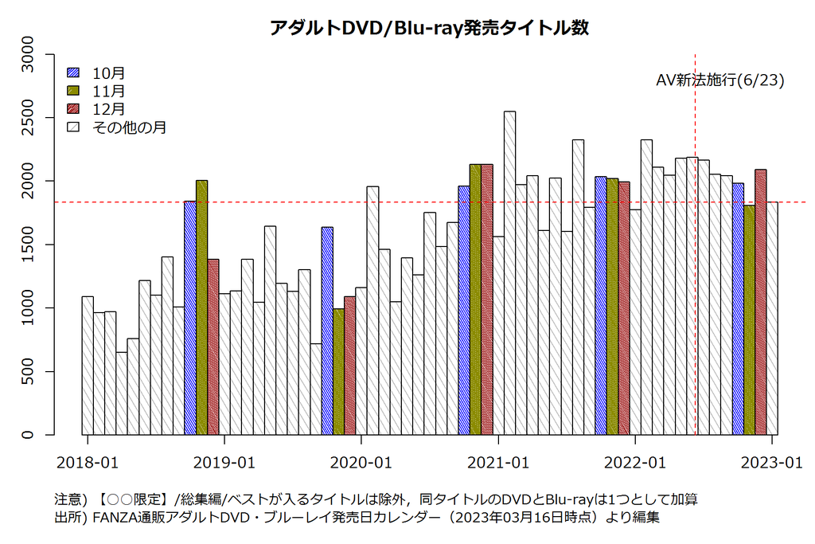

# AV新法改正派女優の状況

- change.orgのAV新法改正署名の呼びかけに発起人・賛同者として名前を連ねたAV女優65名のうち、2023年01月は27名の出演作品が販売/販売予定（2022年01月から2022年12月の平均は28.7名）

## AV新法改正派女優の状況の推移

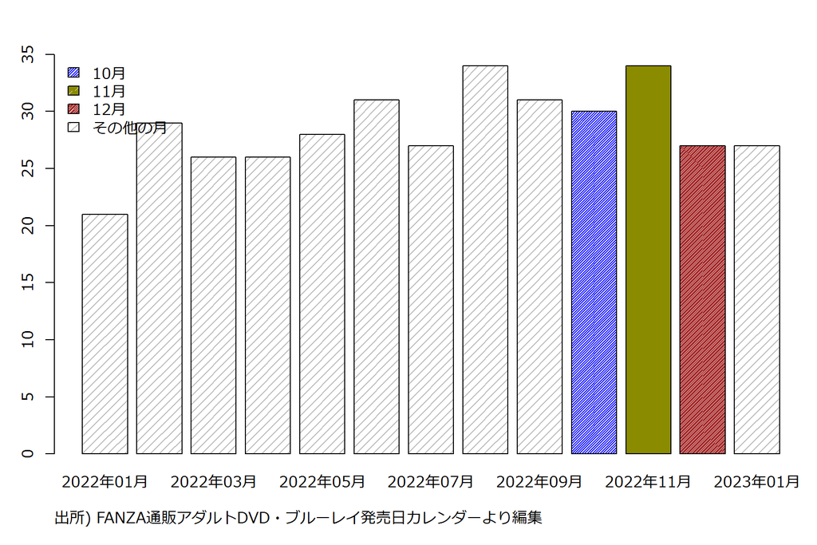

AV出演被害防止・救済法施行後のポルノ発売状況